# Select samples

Alexey Larionov

05 October 2020

# Summary

Remove NFE samples, wecare samples failed sequencing and other filters:

- low concordance with GWAS (when GWAS available)
- duplicates for QC
- carriers of BRCA1/2 and PSALB2
- low call rate in samples (<0.9)

Write the selected samples to a text file (for PCA).  
Exclude non-polymotphic sites appeared after thhe samples removal.

# Start section

```r
# Time
Sys.time()
```

```
## [1] "2020-10-05 20:51:55 BST"
```

```r
# Memory
gc()
```

```
##          used (Mb) gc trigger (Mb) max used (Mb)
## Ncells 408614 21.9     846618 45.3   641700 34.3
## Vcells 780522  6.0    8388608 64.0  1757535 13.5
```

```r
# Clean up
rm(list=ls())
graphics.off()

# Options
options(stringsAsFactors = F)

# Working folders
base_folder <- "/rds/project/erf33/rds-erf33-medgen"
project_folder=file.path(base_folder,"users/alexey/wecare/reanalysis_wo_danish_2020")
data_folder <- file.path(project_folder,"data","s04_add_phenotypes")
scripts_folder <- file.path(project_folder,"scripts","s04_add_phenotypes")
setwd(scripts_folder)

# Required library
library(dplyr)
```

# Load data

```r
load(file.path(data_folder,"s01_add_phenotypes.RData"))
```

# Check data

Note that phenotypes are not syncronised withh other data yet

```r
ls()
```

```
##  [1] "base_folder"               "data_folder"               "full_ad.mx"                "full_dp.mx"                "full_gq.mx"                "full_gt.mx"                "full_header.df"            "full_variants.df"          "phenotypes_with_danish.df" "project_folder"            "scripts_fol…
```

```r
dim(full_header.df)
```

```
## [1] 129   5
```

```r
dim(full_variants.df)
```

```
## [1] 343824    136
```

```r
dim(full_dp.mx)
```

```
## [1] 343824    710
```

```r
dim(full_gq.mx)
```

```
## [1] 343824    710
```

```r
dim(full_gt.mx)
```

```
## [1] 343824    710
```

```r
dim(full_ad.mx)
```

```
## [1] 343824    710
```

```r
dim(phenotypes_with_danish.df)
```

```
## [1] 512  40
```

# Sequenced wecare samples

Ony wecare samples are present in the phenotype table (no NFE samples in the table).

Some of the samples failed sequencing and some of the sequencing results do not represent any sample (e.g. if some samples were accidentally mixed during library preparation).

```r
# Make an index for samples not failed sequencing
sequenced_wecare <- phenotypes_with_danish.df$wes_id %in% colnames(full_gt.mx)

# Count samples
sum(sequenced_wecare)
```

```
## [1] 493
```

```r
sum(!sequenced_wecare)
```

```
## [1] 19
```

# Danish samples

Danish consents do not allow studying known breast cancer risk genes, so danish samples are excluded from this analysis

```r
# Make an index for danish samples
danish <- phenotypes_with_danish.df$danish

# Count samples
sum(danish)
```

```
## [1] 150
```

```r
sum(!danish)
```

```
## [1] 362
```

# Other filters

Samples to be removed:

- low concordance with GWAs
- duplicates added for QC
- BRCA1/2 and PALB2 carriers

Keep eigenvector outliers detected in the previous versions of analysis because eigenvectors will be re-calculated

```r
# Explore filters
phenotypes_with_danish.df %>%
  group_by(filter) %>%
  summarise(count=n()) %>%
  arrange(desc(count))
```

```
## # A tibble: 9 x 2
##   filter                                count
##   <fct>                                 <int>
## 1 pass                                    478
## 2 low_concordance                          14
## 3 BRCA1_carrier                             4
## 4 BRCA2_carrier                             4
## 5 low_concordance, not_annotated            4
## 6 PALB2_carrier                             3
## 7 duplicate                                 2
## 8 eigenvectors_outlier                      2
## 9 low_concordance, eigenvectors_outlier     1
```

```r
# Select samples passed filters
pass_other_filters <- phenotypes_with_danish.df$filter == "pass" |
        phenotypes_with_danish.df$filter == "eigenvectors_outlier"

# Count samples
sum(pass_other_filters)
```

```
## [1] 480
```

```r
sum(!pass_other_filters)
```

```
## [1] 32
```

# Combined filter

```r
# Combined filter (to use on rows of the phenotypes data frame)
combined_filter <- sequenced_wecare & !danish & pass_other_filters
sum(combined_filter)
```

```
## [1] 337
```

```r
sum(!combined_filter)
```

```
## [1] 175
```

```r
# Combined filter names (to use on columns of thhe genotype matrices)
combined_filter_names <- phenotypes_with_danish.df[combined_filter,"wes_id"]
length(combined_filter_names)
```

```
## [1] 337
```

```r
# Clean-up
rm(sequenced_wecare,danish,pass_other_filters)
```

# Sample call rates

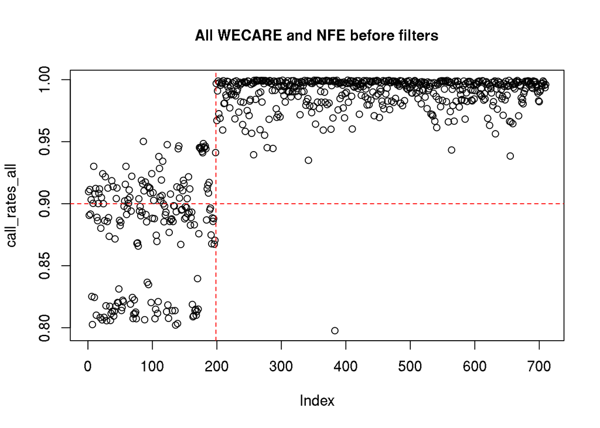

```r
# Function to calculate call rate
call_rate.udf <- function(x){sum(!is.na(x))/length(x)}

# Call rates in all genotypes
call_rates_all <- apply(full_gt.mx,2,call_rate.udf)

plot(call_rates_all, main="All WECARE and NFE before filters")
abline(h=0.9, lty=2, col="red")
abline(v=198.5, lty=2, col="red")
```

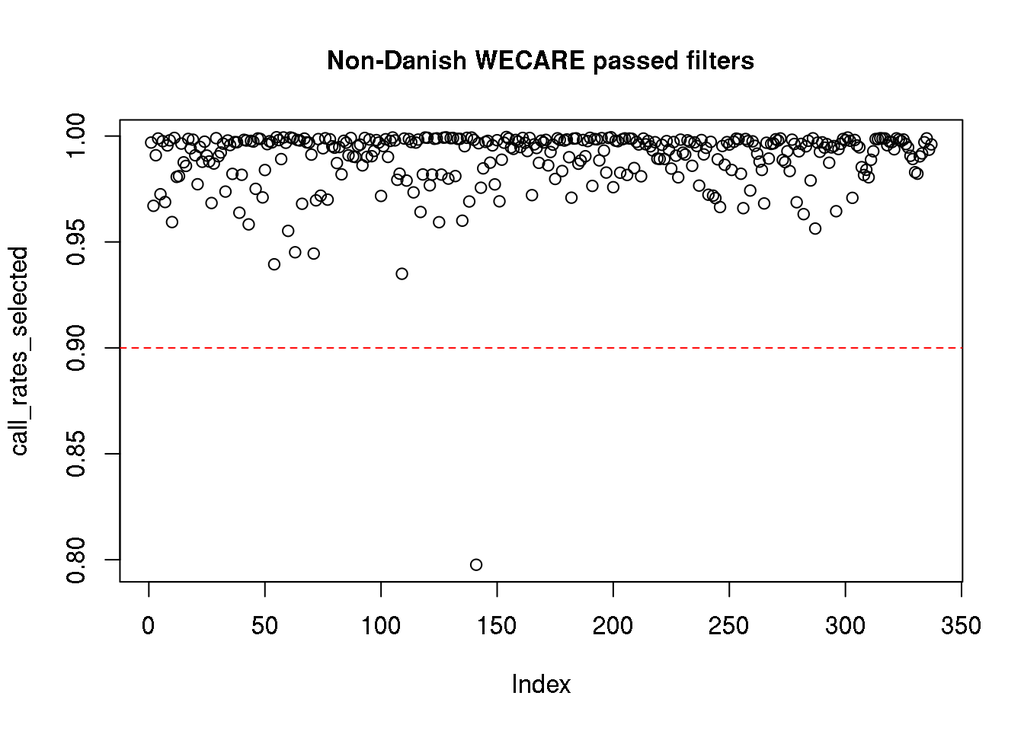

```r
# Call rates in selected non-danish wecare
call_rates_selected <- apply(full_gt.mx[,combined_filter_names],2,call_rate.udf)

plot(call_rates_selected, main="Non-Danish WECARE passed filters")
abline(h=0.9, lty=2, col="red")
```

```r
# The outlier(s)
outliers <- combined_filter_names[call_rates_selected < 0.9]
length(outliers)
```

```
## [1] 1
```

```r
outliers
```

```
## [1] "P2_H10"
```

```r
# Wecare samples with good call rate
low__call_rate <- phenotypes_with_danish.df$wes_id %in% outliers
sum(low__call_rate)
```

```
## [1] 1
```

```r
# Clean-up
rm(call_rate.udf,call_rates_all,call_rates_selected,outliers,combined_filter_names)
```

# Update samples in the dataset

```r
# Update phenotypes
updated_filter <- combined_filter & !low__call_rate
sum(updated_filter)
```

```
## [1] 336
```

```r
# Update phenotypes table
phenotypes.df <- phenotypes_with_danish.df[updated_filter,]
dim(phenotypes.df)
```

```
## [1] 336  40
```

```r
summary(as.factor(phenotypes.df$cc))
```

```
##   0   1
## 172 164
```

```r
# Get names of samples from the updated phenotypes table
selected_samples <- phenotypes.df$wes_id

# Update genotype matrices
selected_dp.mx <- full_dp.mx[,selected_samples]
selected_gq.mx <- full_gq.mx[,selected_samples]
selected_gt.mx <- full_gt.mx[,selected_samples]
selected_ad.mx <- full_ad.mx[,selected_samples]

dim(selected_gt.mx)
```

```
## [1] 343824    336
```

```r
# Write the list of selected samples to a text file (for PCA analysis)
file_name=file.path(data_folder,"s02_selected_samples.txt")
write.table(phenotypes.df$wes_id,
            file_name,quote=F,sep="\t",row.names=F,col.names=F)

# Clean-up
rm(combined_filter,low__call_rate,updated_filter,file_name,selected_samples,
   phenotypes_with_danish.df,full_dp.mx,full_gq.mx,full_gt.mx,full_ad.mx)
```

# Remove non-polymorphic variant sites

After removal of NFE and failed/danish WECARE samples some variant sites are becoming non-polymorphic in the dataset.

```r
# Function to detect uniform vector
# Must return T or F, assuming at least one non-NA value in the vector
uniform.udf <- function(x){min(x,na.rm=T)==max(x,na.rm=T) & any(!is.na(x))}

uniform_sites <- apply(selected_gt.mx,1,uniform.udf)
summary(as.factor(uniform_sites))
```

```
##  FALSE   TRUE
## 243121 100703
```

```r
# Update genotype matrices
dp.mx <- selected_dp.mx[!uniform_sites,]
gq.mx <- selected_gq.mx[!uniform_sites,]
gt.mx <- selected_gt.mx[!uniform_sites,]
ad.mx <- selected_ad.mx[!uniform_sites,]

dim(selected_gt.mx)
```

```
## [1] 343824    336
```

```r
# Update variants
variants.df <- full_variants.df[!uniform_sites,]
dim(variants.df)
```

```
## [1] 243121    136
```

```r
# Clean-up
rm(uniform.udf,uniform_sites,
   selected_dp.mx,selected_gq.mx,selected_gt.mx,selected_ad.mx,
   full_variants.df)
```

# Check data

```r
ls()
```

```
##  [1] "ad.mx"          "base_folder"    "data_folder"    "dp.mx"          "full_header.df" "gq.mx"          "gt.mx"          "phenotypes.df"  "project_folder" "scripts_folder" "variants.df"
```

```r
# Check objects dimentions
dim(full_header.df)
```

```
## [1] 129   5
```

```r
dim(variants.df)
```

```
## [1] 243121    136
```

```r
dim(dp.mx)
```

```
## [1] 243121    336
```

```r
dim(gq.mx)
```

```
## [1] 243121    336
```

```r
dim(gt.mx)
```

```
## [1] 243121    336
```

```r
dim(ad.mx)
```

```
## [1] 243121    336
```

```r
dim(phenotypes.df)
```

```
## [1] 336  40
```

```r
# Check that the tables and matrices are in sync
sum(phenotypes.df$wes_id != colnames(gt.mx))
```

```
## [1] 0
```

```r
sum(phenotypes.df$wes_id != colnames(gq.mx))
```

```
## [1] 0
```

```r
sum(phenotypes.df$wes_id != colnames(dp.mx))
```

```
## [1] 0
```

```r
sum(phenotypes.df$wes_id != colnames(ad.mx))
```

```
## [1] 0
```

```r
sum(variants.df$ID != rownames(gt.mx))
```

```
## [1] 0
```

```r
sum(variants.df$ID != rownames(gq.mx))
```

```
## [1] 0
```

```r
sum(variants.df$ID != rownames(dp.mx))
```

```
## [1] 0
```

```r
sum(variants.df$ID != rownames(ad.mx))
```

```
## [1] 0
```

# Save results

```r
save.image(file.path(data_folder,"s02_select_samples.RData"))

# Save phenotypes data (for showing case/control status in PCA plots)
save(phenotypes.df, file=file.path(data_folder,"s02_selected_phenotypes.RData") )

# Save variants data (for comparing with bcftools polymorphic)
save(variants.df, file=file.path(data_folder,"s02_selected_variants.RData") )
```

# Final section

```r
Sys.time()
```

```
## [1] "2020-10-05 20:57:38 BST"
```

```r
gc()
```

```
##             used   (Mb) gc trigger    (Mb)   max used    (Mb)
## Ncells   3157235  168.7    8176088   436.7    8176088   436.7
## Vcells 369895246 2822.1 1475735465 11259.0 1844357736 14071.4
```